# Bài tập lý thuyết 3

> Họ và tên: Nguyễn Vạn Phúc Huy  
> MSSV: 23110163  
> Lớp: 23TTH (Chiều thứ 6, ca 1)

### Bài 1

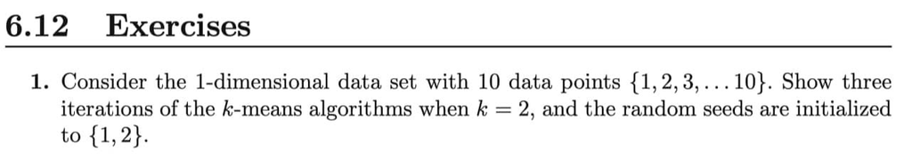

Trước hết, gọi $c_1$ và $c_2$ là vị trí tâm của 2 cụm, $C_1$ và $C_2$ là tập hợp các điểm dữ liệu thuộc 2 cụm tương ứng.

Ta biết rằng trong không gian 1 chiều, điểm biên phân chia (midpoint) giữa 2 tâm được tính bằng $\frac{c_1 + c_2}{2}$. Các điểm nằm bên trái điểm biên sẽ thuộc cụm có tâm nhỏ hơn, nằm bên phải sẽ thuộc cụm có tâm lớn hơn.

Random seeds ta sẽ chọn là $c_1 = 1$ và $c_2 = 2$ cho dễ tính. Điểm biên phân chia sẽ là $\frac{1 + 2}{2} = 1.5$.

### Bài 2

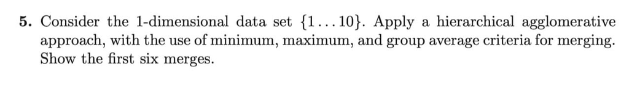

> 1. Single Linkage (minimum)

Single Linkage = khoảng cách giữa hai cụm $A$ và $B$ là khoảng cách nhỏ nhất giữa bất kỳ điểm nào thuộc $A$ và điểm nào thuộc $B$.

- Vì mọi cụm liền kề đều có chung khoảng cách nhỏ nhất là $1$ ở bất kỳ bước nào, thuật toán có thể gộp theo nhiều cách. Ta có:
  - **Merge 1:** $\{1\}$ và $\{2\} \rightarrow \{1, 2\}$
  - **Merge 2:** $\{3\}$ và $\{4\} \rightarrow \{3, 4\}$
  - **Merge 3:** $\{5\}$ và $\{6\} \rightarrow \{5, 6\}$
  - **Merge 4:** $\{7\}$ và $\{8\} \rightarrow \{7, 8\}$
  - **Merge 5:** $\{9\}$ và $\{10\} \rightarrow \{9, 10\}$
  - **Merge 6:** Gộp hai cụm lớn kề nhau (khoảng cách vẫn là 1), ví dụ: $\{1, 2\}$ và $\{3, 4\} \rightarrow \{1, 2, 3, 4\}$
> 2. Complete Linkage (maximum)

Complete Linkage = khoảng cách giữa hai cụm $A$ và $B$ là khoảng cách **lớn nhất** giữa bất kỳ điểm nào thuộc $A$ và điểm nào thuộc $B$.

- Nếu ta gộp cụm $\{1, 2\}$, khoảng cách của nó với cụm $\{3\}$ sẽ là $\max(|1-3|, |2-3|) = 2$.
- Trong khi đó, khoảng cách giữa các điểm đơn lẻ còn lại (ví dụ $\{3\}$ và $\{4\}$) vẫn là $1$. Vì thuật toán luôn chọn khoảng cách nhỏ nhất để gộp ($1 < 2$), nó bắt buộc phải gộp hết các điểm đơn lẻ thành các cặp trước khi gộp tiếp các cụm lớn hơn.
- Do đó, 5 lần gộp đầu tiên chắc chắn là:
  - **Merge 1:** $\{1\}$ và $\{2\} \rightarrow \{1, 2\}$
  - **Merge 2:** $\{3\}$ và $\{4\} \rightarrow \{3, 4\}$
  - **Merge 3:** $\{5\}$ và $\{6\} \rightarrow \{5, 6\}$
  - **Merge 4:** $\{7\}$ và $\{8\} \rightarrow \{7, 8\}$
  - **Merge 5:** $\{9\}$ và $\{10\} \rightarrow \{9, 10\}$
- Sau bước 5, tập các cụm là $\{\{1,2\}, \{3,4\}, \{5,6\}, \{7,8\}, \{9,10\}\}$. Khoảng cách Complete Linkage giữa 2 cụm kề nhau (vd: $\{1,2\}$ và $\{3,4\}$) là $\max(|1-3|, |1-4|, |2-3|, |2-4|) = \max(2, 3, 1, 2) = 3$. Khoảng cách giữa tất cả các cặp kề nhau đều là 3.
  - **Merge 6:** Thuật toán gộp cặp đầu tiên từ trái sang phải: $\{1, 2\}$ và $\{3, 4\} \rightarrow \{1, 2, 3, 4\}$
> 3. Average Linkage (average)

Average Linkage = trung bình của tất cả các khoảng cách giữa từng cặp điểm từ cụm $A$ sang cụm $B$.

- Tương tự Complete Linkage, nếu ta gộp $\{1, 2\}$, khoảng cách từ $\{1, 2\}$ đến $\{3\}$ là $\frac{|1-3| + |2-3|}{2} = \frac{2 + 1}{2} = 1.5$.
- Vì khoảng cách giữa các điểm đơn lẻ còn lại là $1$ ($1 < 1.5$), thuật toán lại tiếp tục ưu tiên gộp các điểm đơn lẻ trước. Do đó, 5 bước gộp đầu tiên giống hệt Maximum.
- Tại bước 6, tính khoảng cách Group Average giữa cụm $\{1,2\}$ và $\{3,4\}$:

$$Distance = \frac{|1-3| + |1-4| + |2-3| + |2-4|}{4} = \frac{2 + 3 + 1 + 2}{4} = 2$$

Khoảng cách này (bằng 2) nhỏ hơn khoảng cách giữa các cụm xa hơn, nên nó sẽ được gộp ở bước tiếp theo.

- Kết quả 6 bước gộp đầu tiên:
  - **Merge 1:** $\{1\}$ và $\{2\} \rightarrow \{1, 2\}$
  - **Merge 2:** $\{3\}$ và $\{4\} \rightarrow \{3, 4\}$
  - **Merge 3:** $\{5\}$ và $\{6\} \rightarrow \{5, 6\}$
  - **Merge 4:** $\{7\}$ và $\{8\} \rightarrow \{7, 8\}$
  - **Merge 5:** $\{9\}$ và $\{10\} \rightarrow \{9, 10\}$
  - **Merge 6:** $\{1, 2\}$ và $\{3, 4\} \rightarrow \{1, 2, 3, 4\}$